# Enrichment Analysis

priesgo

August 9, 2016

## Using Object Oriented (OO) programming

Using OO allows achieving **high cohesion** and **low coupling**, which facilitates all the software development cycle from development to maintenance, including testing. Following the principle **“Don’t repeat yourself”** (https://en.wikipedia.org/wiki/Don't_repeat_yourself) is also enhanced with a good OO design. There are 3 OO models in R, we will be using S4 as it is the model most used in Bioconductor. Furthermore, we want to foster **code reuse** from existing Bioconductor S4 classes.

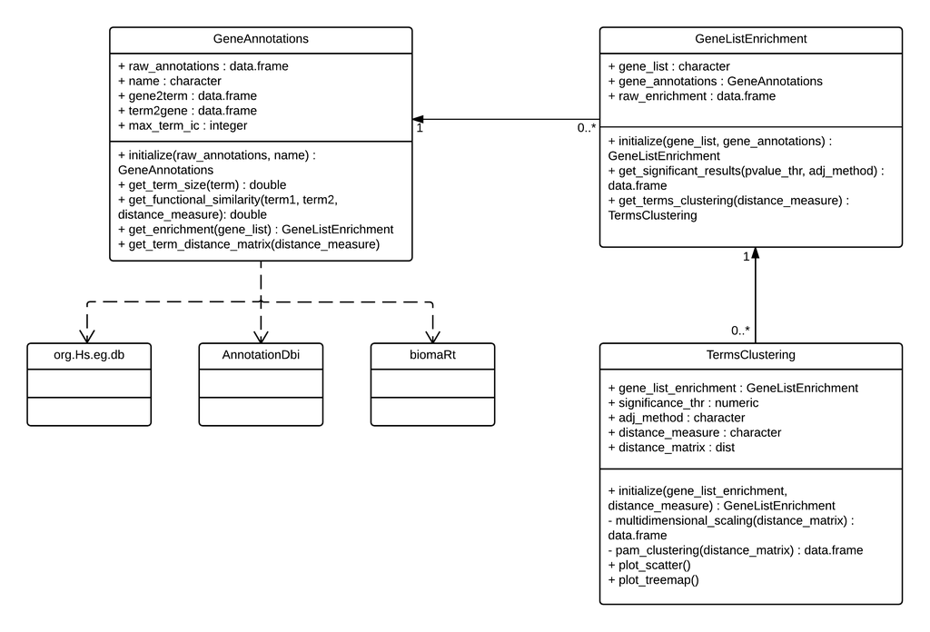

Enrichment class model

## Annotations

This model allows us to support multiple annotations for enrichment. So far the supported annotations based on AnnotationDbi data source and some custom resources are:

- Gene Ontology (from org.Hs.eg.db)
- KEGG pathways (from org.Hs.eg.db)
- OMIM diseases (from org.Hs.eg.db)
- HPO phenotypes (from http://compbio.charite.de/jenkins/job/hpo.annotations.monthly/lastStableBuild/artifact/annotation/ALL_SOURCES_TYPICAL_FEATURES_phenotype_to_genes.txt)

These annotations can be loaded as follows:

```r
goa <- TCGAome::load_goa()
kegg <- TCGAome::load_kegg()
omim <- TCGAome::load_omim()
hpo <- TCGAome::load_hpo()
```

The object created contains the following information:

```r
kegg <- TCGAome::load_kegg()
str(kegg, list.len = 5, vec.len = 5)
```

```
## Formal class 'GeneAnnotations' [package "TCGAome"] with 6 slots
##   ..@ raw_annotations        :'data.frame':  16313 obs. of  2 variables:
##   .. ..$ Gene: chr [1:16313] "A2M" "NAT1" "NAT1" "NAT1" "NAT2" ...
##   .. ..$ Term: chr [1:16313] "04610" "00232" "00983" "01100" "00232" ...
##   ..@ name                   : chr "KEGG-Human"
##   ..@ gene2term              :'data.frame':  5869 obs. of  2 variables:
##   .. ..$ Gene: chr [1:5869] "A2M" "A4GALT" "AAAS" "AACS" "AADAT" ...
##   .. ..$ Term:List of 5869
##   .. .. ..$ 0001: chr "04610"
##   .. .. ..$ 0002: chr [1:2] "00603" "01100"
##   .. .. ..$ 0003: chr "03013"
##   .. .. ..$ 0004: chr "00650"
##   .. .. ..$ 0005: chr [1:4] "00300" "00310" "00380" "01100"
##   .. .. .. [list output truncated]
##   ..@ term2gene              :'data.frame':  229 obs. of  2 variables:
##   .. ..$ Term: chr [1:229] "00010" "00020" "00030" "00040" "00051" ...
##   .. ..$ Gene:List of 229
##   .. .. ..$ 001: chr [1:65] "ADH1A" "ADH1B" "ADH1C" "ADH4" "ADH5" ...
##   .. .. ..$ 002: chr [1:30] "ACLY" "ACO1" "ACO2" "CS" "DLAT" ...
##   .. .. ..$ 003: chr [1:27] "ALDOA" "ALDOB" "ALDOC" "FBP1" "G6PD" ...
##   .. .. ..$ 004: chr [1:32] "ALDH2" "ALDH1B1" "ALDH3A2" "AKR1B1" "GUSB" ...
##   .. .. ..$ 005: chr [1:36] "ALDOA" "ALDOB" "ALDOC" "AKR1B1" "FBP1" ...
##   .. .. .. [list output truncated]
##   ..@ max_term_freq          : int 1130
##   .. [list output truncated]
```

### Metrics

For any term within the **TCGAome::GeneAnnotations** object we can obtain its **relative frequency** of annotation, which might be useful to compute the **Information Content** within a term.

```r
random_kegg_term = kegg@term2gene$Term[runif(1, max = length(kegg@term2gene$Term))]
random_kegg_term
```

```
## [1] "03008"
```

```r
TCGAome::get_term_freq(kegg, random_kegg_term)
```

```
## [1] 0.07079646
```

For any two terms within the GeneAnnotations object we can obtain its **functional similarity** based on the binary distances implemented in TCGAome.

```r
random_kegg_term1 = kegg@term2gene$Term[runif(1, max = length(kegg@term2gene$Term))]
random_kegg_term2 = kegg@term2gene$Term[runif(1, max = length(kegg@term2gene$Term))]
random_kegg_term1
```

```
## [1] "05210"
```

```r
random_kegg_term2
```

```
## [1] "04630"
```

```r
TCGAome::get_functional_similarity(kegg, random_kegg_term1, random_kegg_term2, distance_measure = "UI")
```

```
## [1] 0.06372549
```

The supported binary distances are: UI, cosine, Bray-Curtis and binary.

This model should be extended to support **semantic similarity** measures based on the ontology structure. This is a special case for some of these annotation resources which are also backed by an ontology, like GO and HPO. On the previous implementation of TCGAome we used **GoSemSim** for the semantic similarity within GO terms. We need to study if this can be easily extended to other ontologies.

### Extend annotation support

It is relatively simple to extend the support to additional annotations, we just need to provide the association between genes and terms in a tall-skinny data frame with columns “Gene” and “Term”.

```r
uniKeys <- AnnotationDbi::keys(org.Hs.eg.db::org.Hs.eg.db, keytype="SYMBOL")
cols <- c("PATH")
kegg_raw <- AnnotationDbi::select(org.Hs.eg.db::org.Hs.eg.db, keys=uniKeys, columns=cols, keytype="SYMBOL")
kegg_raw <- kegg_raw[, c(1, 2)]
colnames(kegg_raw) <- c("Gene", "Term")
kegg <- new("GeneAnnotations", raw_annotations = kegg_raw, name="KEGG-Human")
```

## Enrichment

The previous TCGAome version used the package **topGO** for computing the enrichment of GO terms. This package is limited to GO. The computation employed was a Fisher’s test, we were not making use of the advanced functionality in topGO. Thus, in order to gain flexibility the enrichment computation was reimplemented inside the class **TCGAome::GeneListEnrichment**.

We can compute enrichment for a given list of genes based on a preloaded annotation:

```r
gene_list <- c("ZNF638", "HNRNPU", "PPIAL4G", "RAPH1", "USP7", "SUMO1P3",
          "TMEM189.UBE2V1", "ZNF837", "LPCAT4", "ZFPL1", "STAT3", "XRCC1",
          "STMN1", "PGR", "RB1", "KDR", "YBX1", "YAP1", "FOXO3", "SYK", "RAB17",
          "TTC8", "SLC22A5", "C3orf18", "ANKRA2", "LBR", "B3GNT5", "ANP32E",
          "JOSD1", "ZNF695", "ESR1", "INPP4B", "PDK1", "TSC2", "AR", "HSPA1A",
          "CDH3", "SMAD4", "CASP7", "GMPS", "NDC80", "EZH2", "MELK", "CDC45",
          "CRY2", "KLHDC1", "MEIS3P1", "FBXL5", "EHD2", "CCNB1", "GSK3A",
          "DVL3", "NFKB1", "COL6A1", "CCND1", "BAK1")
kegg_enrichment <- TCGAome::get_enrichment(kegg, gene_list = gene_list)
str(kegg_enrichment, list.len = 5, vec.len = 5)
```

```
## Formal class 'GeneListEnrichment' [package "TCGAome"] with 3 slots
##   ..@ gene_list       : chr [1:56] "ZNF638" "HNRNPU" "PPIAL4G" "RAPH1" "USP7" ...
##   ..@ gene_annotations:Formal class 'GeneAnnotations' [package "TCGAome"] with 6 slots
##   .. .. ..@ raw_annotations        :'data.frame':    16313 obs. of  2 variables:
##   .. .. .. ..$ Gene: chr [1:16313] "A2M" "NAT1" "NAT1" "NAT1" "NAT2" ...
##   .. .. .. ..$ Term: chr [1:16313] "04610" "00232" "00983" "01100" "00232" ...
##   .. .. ..@ name                   : chr "KEGG-Human"
##   .. .. ..@ gene2term              :'data.frame':    5869 obs. of  2 variables:
##   .. .. .. ..$ Gene: chr [1:5869] "A2M" "A4GALT" "AAAS" "AACS" "AADAT" ...
##   .. .. .. ..$ Term:List of 5869
##   .. .. .. .. ..$ 0001: chr "04610"
##   .. .. .. .. ..$ 0002: chr [1:2] "00603" "01100"
##   .. .. .. .. ..$ 0003: chr "03013"
##   .. .. .. .. ..$ 0004: chr "00650"
##   .. .. .. .. ..$ 0005: chr [1:4] "00300" "00310" "00380" "01100"
##   .. .. .. .. .. [list output truncated]
##   .. .. ..@ term2gene              :'data.frame':    229 obs. of  2 variables:
##   .. .. .. ..$ Term: chr [1:229] "00010" "00020" "00030" "00040" "00051" ...
##   .. .. .. ..$ Gene:List of 229
##   .. .. .. .. ..$ 001: chr [1:65] "ADH1A" "ADH1B" "ADH1C" "ADH4" "ADH5" ...
##   .. .. .. .. ..$ 002: chr [1:30] "ACLY" "ACO1" "ACO2" "CS" "DLAT" ...
##   .. .. .. .. ..$ 003: chr [1:27] "ALDOA" "ALDOB" "ALDOC" "FBP1" "G6PD" ...
##   .. .. .. .. ..$ 004: chr [1:32] "ALDH2" "ALDH1B1" "ALDH3A2" "AKR1B1" "GUSB" ...
##   .. .. .. .. ..$ 005: chr [1:36] "ALDOA" "ALDOB" "ALDOC" "AKR1B1" "FBP1" ...
##   .. .. .. .. .. [list output truncated]
##   .. .. ..@ max_term_freq          : int 1130
##   .. .. .. [list output truncated]
##   ..@ raw_enrichment  :'data.frame': 229 obs. of  2 variables:
##   .. ..$ Term  : chr [1:229] "00010" "00020" "00030" "00040" "00051" ...
##   .. ..$ pvalue: num [1:229] 1 1 1 1 1 1 1 1 1 1 1 1 ...
```

Or alternatively:

```r
kegg_enrichment <- new("GeneListEnrichment", gene_annotations = kegg, gene_list = gene_list)
```

And extract significant results:

```r
TCGAome::get_significant_results(kegg_enrichment, significance_thr = 0.05, adj_method = "none")
```

```
##      Term       pvalue   adj_pvalue
## 112 04110 0.0061590702 0.0061590702
## 114 04115 0.0263433137 0.0263433137
## 200 05145 0.0360194893 0.0360194893
## 204 05200 0.0334067677 0.0334067677
## 207 05212 0.0004880615 0.0004880615
## 210 05215 0.0098109166 0.0098109166
## 215 05220 0.0048909621 0.0048909621
## 216 05221 0.0165441885 0.0165441885
## 217 05222 0.0464121410 0.0464121410
## 218 05223 0.0143072153 0.0143072153
```

## Visualizing enrichment results (clustering + MDS)

```r
kegg_term_clustering <- new("TermsClustering", kegg_enrichment, "UI", significance_thr = 0.05, adj_method = "none")
str(kegg_term_clustering@distance_matrix, vec.len = 5)
```

```
## Class 'dist'  atomic [1:45] 0.857 0.988 0.923 0.916 0.924 0.881 ...
##   ..- attr(*, "Labels")= chr [1:10] "04110" "04115" "05145" "05200" "05212" ...
##   ..- attr(*, "Size")= int 10
##   ..- attr(*, "call")= language as.dist.default(m = distance_matrix)
##   ..- attr(*, "Diag")= logi FALSE
##   ..- attr(*, "Upper")= logi FALSE
```

```r
str(kegg_term_clustering@significant_results, vec.len = 5)
```

```
## 'data.frame':    10 obs. of  7 variables:
##  $ Term      : chr  "04110" "04115" "05145" "05200" "05212" ...
##  $ pvalue    : num  0.006159 0.026343 0.036019 0.033407 0.000488 0.009811 ...
##  $ adj_pvalue: num  0.006159 0.026343 0.036019 0.033407 0.000488 0.009811 ...
##  $ Cluster   : int  1 1 2 2 2 2 2 2 2 2
##  $ x         : num  -0.4665 -0.5274 -0.0614 -0.0252 0.1922 0.1868 ...
##  $ y         : num  -0.2289 -0.1601 0.495 0.2077 -0.0453 -0.1264 ...
##  $ Freq      : num  0.1097 0.0602 0.1168 0.2885 0.0619 0.0788 ...
```

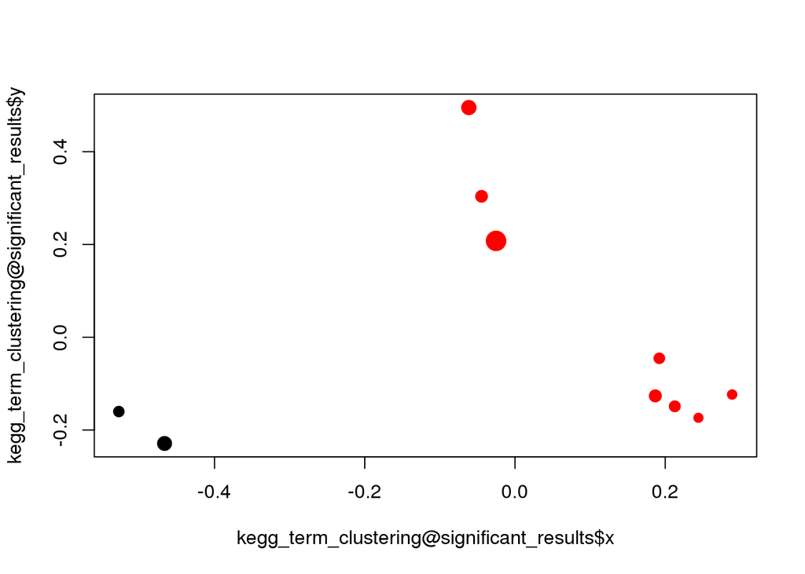

```r
plot(kegg_term_clustering@significant_results$x,
     kegg_term_clustering@significant_results$y,
     col = kegg_term_clustering@significant_results$Cluster,
     cex = log(kegg_term_clustering@significant_results$Freq * 100),
     pch=20)
```